# Visualisierungen der Suicide Daten von 1985-2016

Philipp Dalheimer, Thomas Jäger

### Ausgangssituation

In diesem Projekt beschäftigen wir uns mit der Visualisierung des Datensatz “Suicide Rates Overview von 1985-2016”. Der Datensatz besteht ursprünglich aus vier anderen Datensätzen, die zusammengefügt wurden, um mögliche Zusammenhänge zu erkennen.  
Zu finden ist er unter https://www.kaggle.com/russellyates88/suicide-rates-overview-1985-to-2016

**Quellen**

United Nations Development Programm. (2018). Human development index (HDI):  
http://hdr.undp.org/en/indicators/137506

World Bank. (2018). World development indicators: GDP (current US$) by country:1985 to 2016: http://databank.worldbank.org/data/source/world-development-indicators#

[Szamil]. (2017). Suicide in the Twenty-First Century [dataset]:  
https://www.kaggle.com/szamil/suicide-in-the-twenty-first-century/notebook

World Health Organization. (2018). Suicide prevention: http://www.who.int/mental_health/suicide-prevention/en/

Geschlechterunterschiede bei Suizid und Suizidalität/Fachartikel (2017, uni-muenster.de) https://gendermedwiki.uni-muenster.de/mediawiki/index.php/Geschlechterunterschiede_bei_Suizid_und_Suizidalit%C3%A4t/Fachartikel

### Unsere Ziele

Durch die Bearbeitung und Visualisierung dieses Datensatzes erhoffen wir uns einen tieferen Einblick in das genannte Thema und versuchen folgende Fragestellungen herauszufinden:

- Wo fanden die meisten Selbstmorde statt?
- Gibt es einen Zusammenhang zwischen Alter & Geschlecht?
- Gibt es mehrere Suizide, wenn die Population höher ist?
- Was könnten Gründe für die Selbstmorde gewesen sein?
- Gibt es einen Zusammenhang zwischen reichen/armen Ländern und Suiziden?

### Beschreibung der Daten

Der Datensatz *“Suicide Rates Overview 1985 to 2016”* beinhaltet 12 Spalten und 27.820 Zeilen. Die Zeilen sind unterteilt in:

1. country *(Land)*
2. year *(Jahr)*
3. sex *(Geschlecht)*
4. age *(Alter)*
5. suicides_no *(Anzahl der Suizide)*
6. population *(Population der Gruppe in der Spalte; Bsp.: Männlich, 75+, Brasilien, Jahr 2000)*
7. suicides/100k pop *(Suizide pro 100k Population)*
8. country-year *(Zusammensetzung aus Land und Jahr)*
9. HDI for year *(Human Development Index: Index der menschlichen Entwicklung)*
10. gdp_for_year ($) *(Bruttoinlandsprodukt)*
11. gdp_per_capita ($) *(Bruttoinlandsprodukt pro Kopf)*
12. generation *(Die Generationen sind nachfolgend in den einzelnen Unterpunkten weiter erklärt)*
    - G.I. Generation: Geburt zwischen 1901 - 1927
    - Silent: Geburt zwischen 1925 - 1942
    - Boomers: Geburt zwischen 1946 - 1964
    - Generation X: Geburt zwischen 1960 - 1980
    - Millennials: Geburt zwischen 1980 - frühe 2000
    - Generation Z: Geburt zwischen Mitte 1990 - 2000er

### Beobachtungen und Bereinigen der Daten

Beim Betrachten der master.csv sind uns folgende Missstände aufgefallen, die wir gerne bereinigen würden:

- 7 Länder haben nur <= 3 Jahre an Daten
- 2016 hatten nur wenige Länder Daten -> Jahr nicht betrachten
- *HDI for year* mehr als 2/3 fehlende Werte
- *Africa* hat sehr wenige Länder, welche Daten haben
- Kontinente mit dem Package *countrycode* hinzugefügt

```r
library(tidyverse)
library(countrycode)   # um Kontinente zu erzeugen
library(grid)
library(lattice)


# Laden der Daten
data <- read_csv("../data/master.csv")
# Daten bereinigen und entfernen der Spalte "HDI for year"
# Umbennen der anderern Spalten

data <- data %>%
  select(-c(`HDI for year`, `suicides/100k pop`)) %>%
  rename(gdp_for_year = `gdp_for_year ($)`,
         gdp_per_capita = `gdp_per_capita ($)`,
         country_year = `country-year`) %>%
  as.data.frame()

# das Jahr 2016 aus data entfernen, da in vielen Ländern dieses Jahr fehlte und in denen, welche 2016 hatten, fehlten andere Daten

data <- data %>%
  filter(year != 2016) %>%
  select(-country_year)


# Länder mit <= 3 Jahren Gesamt-Daten entfernen

minimum_years <- data %>%
  group_by(country) %>%
  summarize(rows = n(),
            years = rows / 12) %>%
  arrange(years)

data <- data %>%
  filter(!(country %in% head(minimum_years$country, 7)))

# das Datenset ein wenig kleiner machen
data$age <- gsub(" years", "", data$age)        # gsub um Strings zu ersetzen
data$sex <- ifelse(data$sex == "male", "Male", "Female")

# Kontinente data
data$continent <- countrycode(sourcevar = data[, "country"],
                              origin = "country.name",
                              destination = "continent")



# nominale daten (country, sex, continent)
data_nominal <- c('country','sex','continent')
data[data_nominal] <- lapply(data[data_nominal], function(x){factor(x)})


# ordinale daten (alter, generation)
data$age <- factor(data$age,
                   ordered = T,
                   levels = c("5-14",
                              "15-24",
                              "25-34",
                              "35-54",
                              "55-74",
                              "75+"))

# generation ordinal
data$generation <- factor(data$generation,
                   ordered = T,
                   levels = c("G.I. Generation",
                              "Silent",
                              "Boomers",
                              "Generation X",
                              "Millenials",
                              "Generation Z"))


data <- as_tibble(data)  # as_tibble beeser/gleich als as_data_frame()


# globaler durchschnitt
global_average <- (sum(as.numeric(data$suicides_no)) / sum(as.numeric(data$population))) * 100000


# die finalen daten anschauen
glimpse(data)
```

```
## Observations: 27,492
## Variables: 10
## $ country        <fct> Albania, Albania, Albania, Albania, Albania, Al...
## $ year           <dbl> 1987, 1987, 1987, 1987, 1987, 1987, 1987, 1987,...
## $ sex            <fct> Male, Male, Female, Male, Male, Female, Female,...
## $ age            <ord> 15-24, 35-54, 15-24, 75+, 25-34, 75+, 35-54, 25...
## $ suicides_no    <dbl> 21, 16, 14, 1, 9, 1, 6, 4, 1, 0, 0, 0, 2, 17, 1...
## $ population     <dbl> 312900, 308000, 289700, 21800, 274300, 35600, 2...
## $ gdp_for_year   <dbl> 2156624900, 2156624900, 2156624900, 2156624900,...
## $ gdp_per_capita <dbl> 796, 796, 796, 796, 796, 796, 796, 796, 796, 79...
## $ generation     <ord> Generation X, Silent, Generation X, G.I. Genera...
## $ continent      <fct> Europe, Europe, Europe, Europe, Europe, Europe,...
```

### Globale Analyse

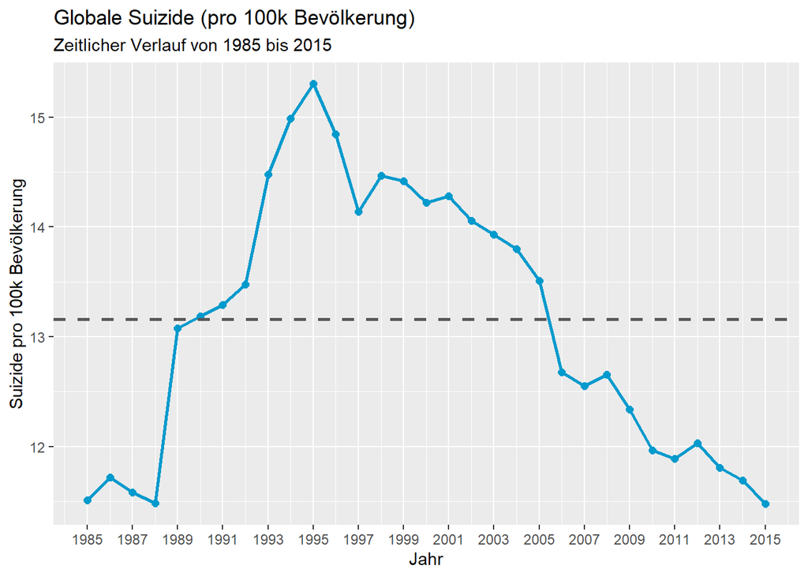

Abbildung 1: Globale Suizide (pro 100k Bevölkerung) / Gestrichelte Linie ist der globale Durchschnitt

```r
data %>%
  group_by(year) %>%
  summarize(population = sum(population),
            suicides = sum(suicides_no),
            suicides_per_100k = (suicides / population) * 100000) %>%
  ggplot(aes(x = year, y = suicides_per_100k)) +
  geom_line(col = "deepskyblue3", size = 1) +
  geom_point(col = "deepskyblue3", size = 2) +
  geom_hline(yintercept = global_average, linetype = 2, color = "grey35", size = 1) +     # global average als gestrichelte Linie
  labs(title = "Globale Suizide (pro 100k Bevölkerung)",
       subtitle = "Zeitlicher Verlauf von 1985 bis 2015",
       x = "Jahr",
       y = "Suizide pro 100k Bevölkerung") +
  scale_x_continuous(breaks = seq(1985, 2015, 2)) +
  scale_y_continuous(breaks = seq(10, 20))
```

**Was uns auffällt:**  
Der Höchstwert der Suizidrate pro 100k Bevölkerung lag im Jahre 1995 bei 15.3 Suiziden. Ab 1995 sinkt die Rate stetig. Ab und an gibt es mal ein Jahr, bei dem die Rate wieder um 0.5 steigt. Diese sinkt jedoch im darauf folgenden Jahr wieder bis sie schließlich in 2015 auf 11.5 Suizide pro 100k Bevölkerung absteigt (ca. 25% Abstieg).

### Selbstmorde nach Kontinent

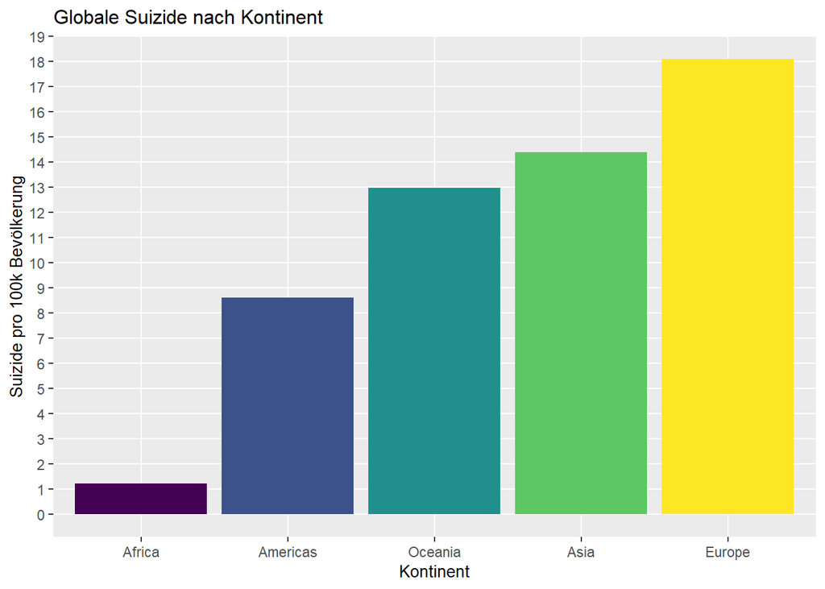

Abbildung 2: Globale Suizide nach Kontinent

```r
continent <- data %>%
  group_by(continent) %>%
  summarize(suicide_per_100k = (sum(as.numeric(suicides_no)) / sum(as.numeric(population))) * 100000) %>%
  arrange(suicide_per_100k)

continent$continent <- factor(continent$continent, ordered = T, levels = continent$continent)

continent_plot <- ggplot(continent, aes(x = continent, y = suicide_per_100k, fill = continent)) +
  geom_bar(stat = "identity") +
  labs(title = "Globale Suizide nach Kontinent",
  x = "Kontinent",
  y = "Suizide pro 100k Bevölkerung",
  fill = "Continent") +
  theme(legend.position = "none", title = element_text(size = 10)) +
  scale_y_continuous(breaks = seq(0, 20, 1), minor_breaks = F)

continent_plot
```

Wir erkennen anhand der oberen Abbildung 2, dass die meisten Suizide im Zeitraum von 1985 bis 2015 in Europa stattfanden. Wie sieht nun der zeitliche Verlauf der einzelnen Bereiche aus?

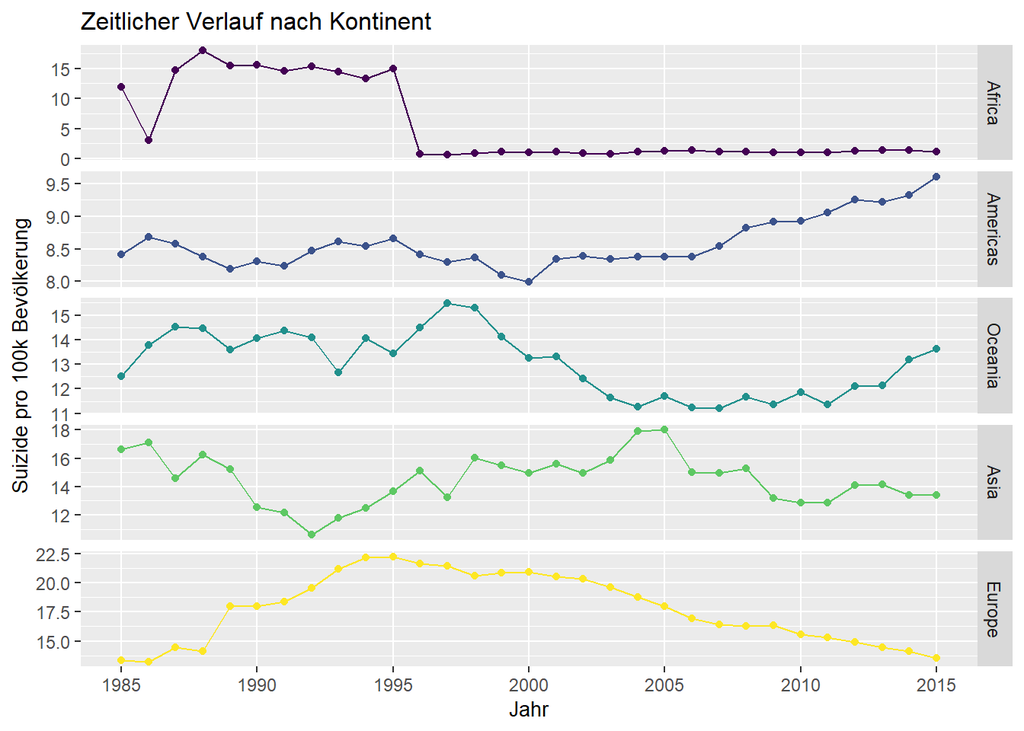

Abbildung 3: Zeitlicher Verlauf nach Kontinent

```r
continent_time <- data %>%
  group_by(year, continent) %>%
  summarize(suicide_per_100k = (sum(as.numeric(suicides_no)) / sum(as.numeric(population))) * 100000)

continent_time$continent <- factor(continent_time$continent, ordered = T, levels = continent$continent)

continent_time_plot <- ggplot(continent_time, aes(x = year, y = suicide_per_100k, col = factor(continent))) +
  facet_grid(continent ~ ., scales = "free_y") +
  geom_line() +
  geom_point() +
  labs(title = "Zeitlicher Verlauf nach Kontinent",
       x = "Jahr",
       y = "Suizide pro 100k Bevölkerung",
       color = "Continent") +
  theme(legend.position = "none", title = element_text(size = 10)) +
  scale_x_continuous(breaks = seq(1985, 2015, 5), minor_breaks = F)

continent_time_plot
```

Direkt fällt wie auch in Abbildung 2 auf, dass Europa eine der höchsten Suizidraten im Vergleich zu den anderen Kontinenten hat. Sie steigt stetig ab und hat seit 1995 um ca. 40% abgenommen. 2015 war die Suizidrate ählich der von Asien oder Ozeanien. Weiterhin ist auffallend, dass die Trends von Ozeanien und Amerika steigend sind.

Folglich haben wir uns die Frage gestellt, wie die globale Suizidrate betrachtet auf das Geschlecht aussehen könnte.

### Selbstmorde nach Geschlecht

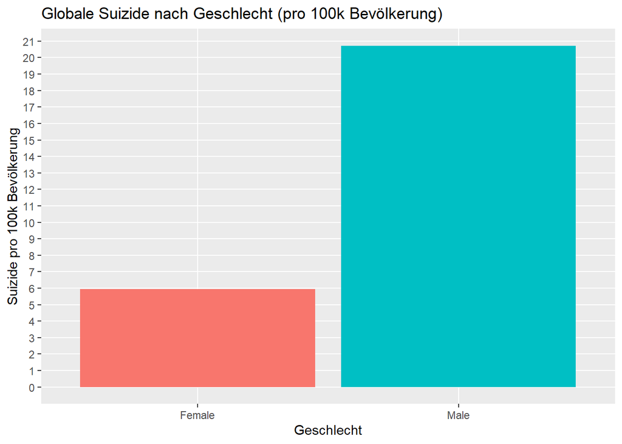

Abbildung 4: Globale Suizide nach Geschlecht (pro 100k Bevölkerung)

```r
sex_plot <- data %>%
  group_by(sex) %>%
  summarize(suicide_per_100k = (sum(as.numeric(suicides_no)) / sum(as.numeric(population))) * 100000) %>%
ggplot(aes(x = sex, y = suicide_per_100k, fill = sex)) +
  geom_bar(stat = "identity") +
  labs(title = "Globale Suizide nach Geschlecht (pro 100k Bevölkerung)",
       x = "Geschlecht",
       y = "Suizide pro 100k Bevölkerung") +
  theme(legend.position = "none") +
  scale_y_continuous(breaks = seq(0, 25), minor_breaks = F)

sex_plot
```

Abbildung 4 bestätigte unsere Vermutung, dass die Suizidrate bei Männern weitaus höher ist, als die von Frauen.

> Der größte Risikofaktor für einen Suizid ist eine psychische Erkrankung. Vor allem Depression, aber auch schizophrene oder Suchterkrankungen erhöhen das Risiko eines Suizides enorm. […] Obwohl Depressionen bei Frauen ungefähr doppelt so häufig diagnostiziert werden wie bei Männern, liegt der Anteil derjenigen Männer die infolge einer Depression Suizid begangen haben mit 60 bis 70 Prozent deutlich über dem Anteil an Frauen.

So begründet *gendermedwiki.uni-muenster.de* die hohe Selbstmordrate bei Männern.

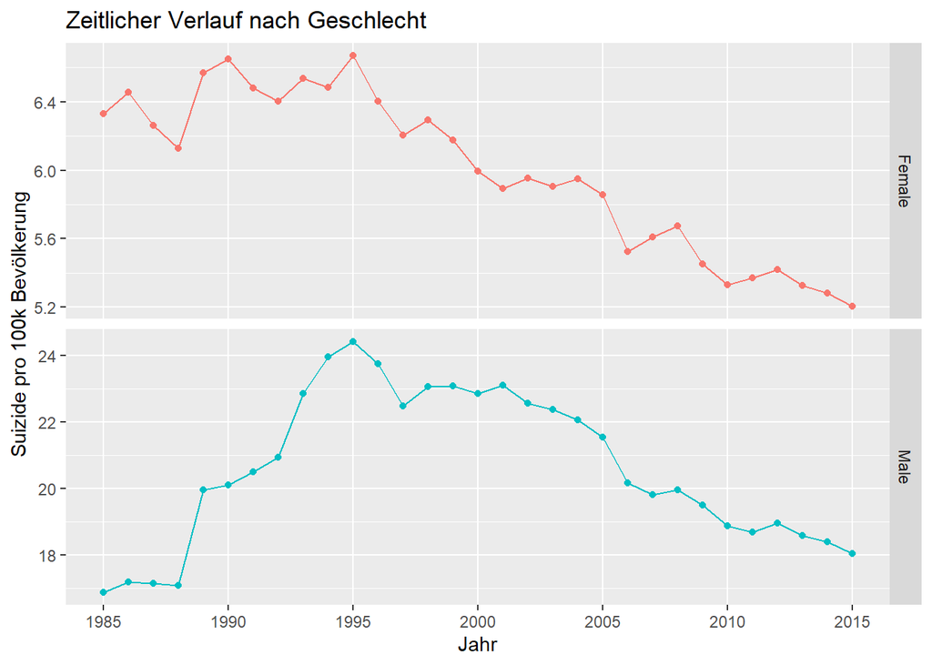

Abbildung 5: Zeitlicher Verlauf nach Geschlecht

```r
sex_time_plot <- data %>%
  group_by(year, sex) %>%
  summarize(suicide_per_100k = (sum(as.numeric(suicides_no)) / sum(as.numeric(population))) * 100000) %>%
  ggplot(aes(x = year, y = suicide_per_100k, col = factor(sex))) +
  facet_grid(sex ~ ., scales = "free_y") +
  geom_line() +
  geom_point() +
  labs(title = "Zeitlicher Verlauf nach Geschlecht",
       x = "Jahr",
       y = "Suizide pro 100k Bevölkerung",
       color = "Geschlecht") +
  theme(legend.position = "none") +
  scale_x_continuous(breaks = seq(1985, 2015, 5), minor_breaks = F)

sex_time_plot
```

Der Suizidverlauf von 1985 bis 2015 sinkt wie auch der globale Kontinent Trend (Abb. 3) ab 1995. Bei den Männern bis hin zu 18 Suizide pro 100.000 Bevölkerung und bei den Frauen auf bis zu 5.2 Suizide pro 100.000 Bevölkerung. Schauen wir uns nun die folgende Abbildung 6 an, stellen wir fest, dass die Länder mit den meisten Suiziden pro 100.000 Bevölkerung Litauen und Russland sind. Dies könnte natürlich auch der große Ausschlag 1995 verursacht haben.

### Selbstmorde nach Land

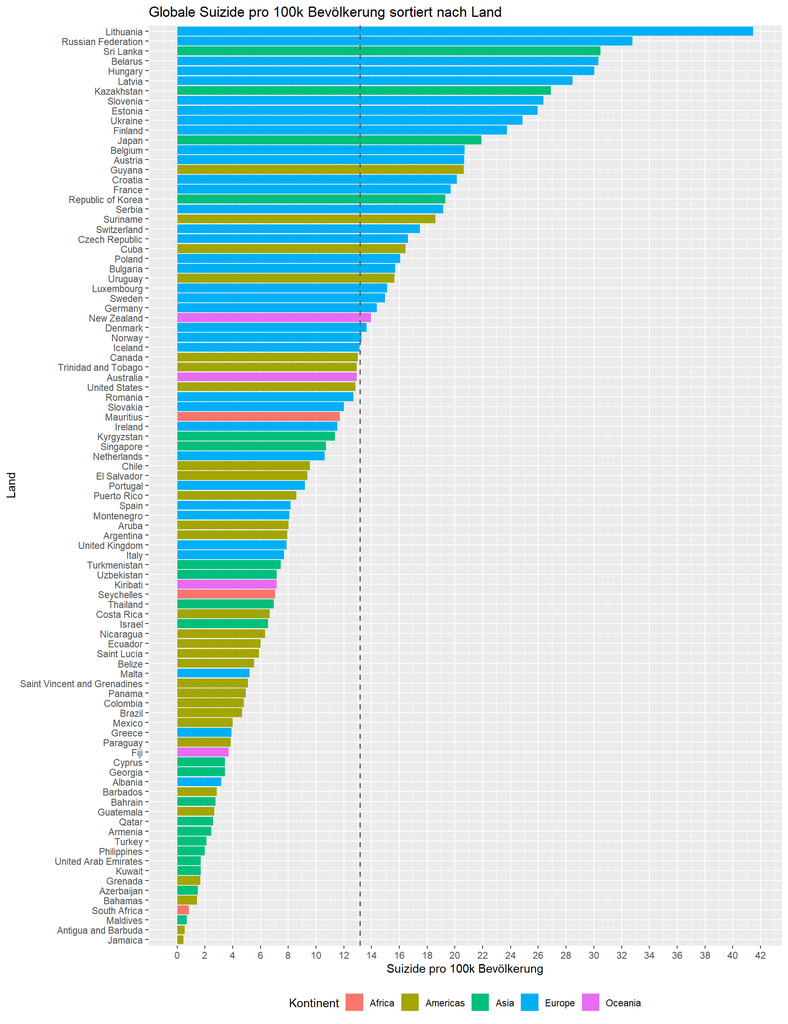

Abbildung 6: Globale Suizide pro 100k Bevölkerung sortiert nach Land

```r
# mit "fig.width = 10, fig.height = 13" erreichen wir, dass das Bild richtig angezeigt wird und nicht zu klein ist
country <- data %>%
  group_by(country, continent) %>%
  summarize(n = n(),
            suicide_per_100k = (sum(as.numeric(suicides_no)) / sum(as.numeric(population))) * 100000) %>%
  arrange(desc(suicide_per_100k))

country$country <- factor(country$country,
                          ordered = T,
                          levels = rev(country$country))

ggplot(country, aes(x = country, y = suicide_per_100k, fill = continent)) +
  geom_bar(stat = "identity") +
  geom_hline(yintercept = global_average, linetype = 2, color = "grey35", size = 0.6) +
  labs(title = "Globale Suizide pro 100k Bevölkerung sortiert nach Land",
       x = "Land",
       y = "Suizide pro 100k Bevölkerung",
       fill = "Kontinent") +
  coord_flip() + #Achsen drehen, weil sont Land nicht zu lesen ist
  scale_y_continuous(breaks = seq(0, 45, 2)) +
  scale_x_discrete("Land", labels =  , position = "bottom") +
  theme(legend.position = "bottom")
```

### Unterschiede der Geschlechter, geordnet nach Kontinent

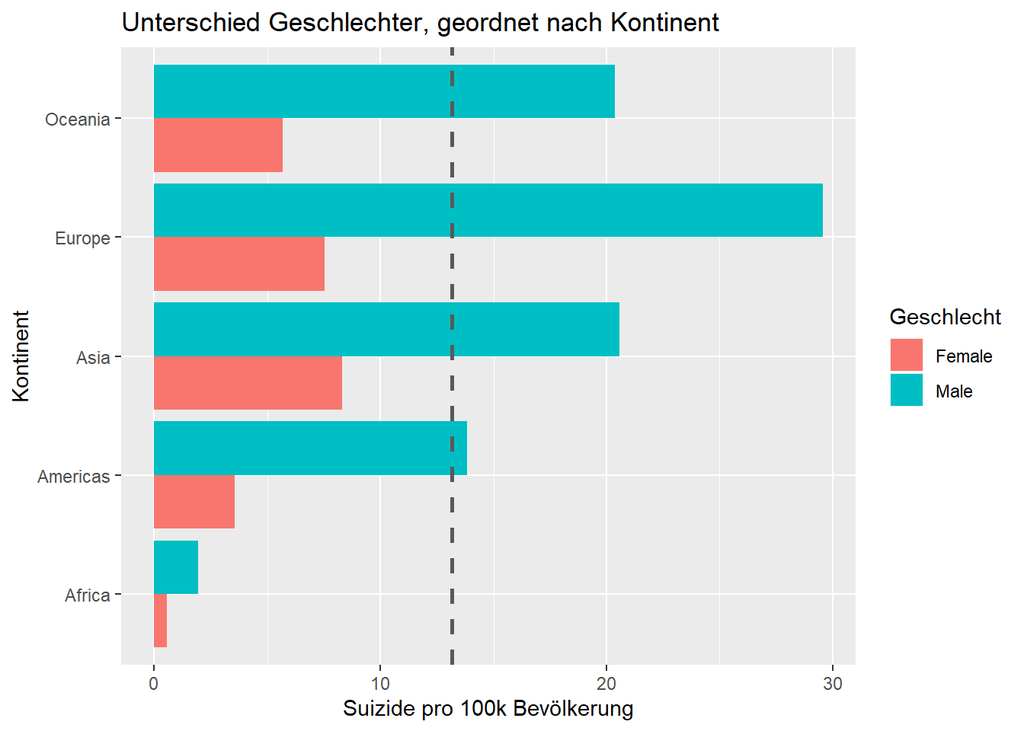

Abbildung 7: Unterschied Geschlechter, geordnet nach Kontinent

```r
data %>%
  group_by(continent, sex) %>%
  summarize(n = n(),
            suicides = sum(as.numeric(suicides_no)),
            population = sum(as.numeric(population)),
            suicide_per_100k = (suicides / population) * 100000) %>%
  ggplot(aes(x = continent, y = suicide_per_100k, fill = sex)) +
  geom_bar(stat = "identity", position = "dodge") +
  geom_hline(yintercept = global_average, linetype = 2, color = "grey35", size = 1) +
  labs(title = "Unterschied Geschlechter, geordnet nach Kontinent",
   x = "Kontinent",
   y = "Suizide pro 100k Bevölkerung",
   fill = "Geschlecht") +
  coord_flip()
```

### Fazit

Der allgemeine Trend der Suizide von 1985 bis 2015 sinkt. 1995 gab es eine sehr hohe Selbstmordrate. Allgemein betrachtet kann man aus den Daten lesen, dass die Selbstmordrate bei Männern höher ist als bei Frauen. Dieses Phänomen könnte eventuell daher kommen, dass sich Frauen tendenziell öfter anderen Menschen anvertrauen (z.B. Psychologen) als Männer. Aus den Daten konnten wir weiterhin herausfinden, dass in Deutschland die Suizidrate im Zeitraum von 1985 bis 2015 noch im “Mittelfeld” liegt (Abb. 6) und an erster Stelle steht Litauen.

Tendenziell liegt die Selbstmordrate pro 100.000 Bevölkerung in Europa höher als beispielsweise in Afrika (Abb. 2). Aufgefallen ist hier, dass seit 1995/1996 Afrika eine Suizidrate von ca. 0 Suiziden pro 100k Bevölkerung hat, was sehr ungewöhnlich ist.